# Les crèches favorisent-elles la natalité ? Une analyse départementale en France (2017–2023)

## 5.2 Accueil collectif versus accueil individuel

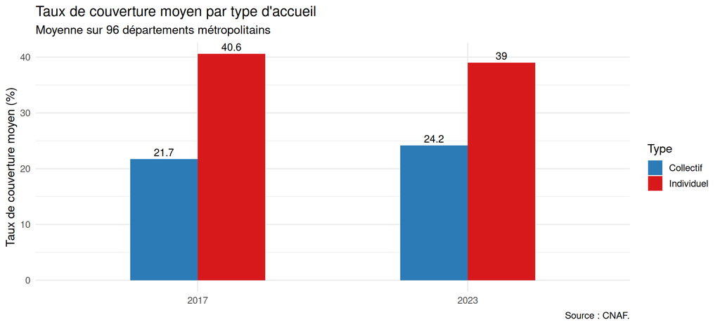

```r
df_type <- bind_rows(
  final17 |>
    select(département,
           Collectif  = Taux.de.couv.collectif,
           Individuel = Taux.de.couv.individuel) |>
    pivot_longer(-département, names_to = "Type", values_to = "taux") |>
    mutate(Année = "2017"),
  final23 |>
    select(département,
           Collectif  = Taux.de.couv.collectif,
           Individuel = Taux.de.couv.individuel) |>
    pivot_longer(-département, names_to = "Type", values_to = "taux") |>
    mutate(Année = "2023")
)

df_type |>
  group_by(Année, Type) |>
  summarise(moy = mean(taux, na.rm = TRUE), .groups = "drop") |>
  ggplot(aes(x = Année, y = moy, fill = Type)) +
  geom_col(position = "dodge", width = 0.5) +
  geom_text(aes(label = round(moy, 1)), position = position_dodge(width = 0.5),
            vjust = -0.4, size = 4) +
  scale_fill_manual(values = c("Collectif" = "#2c7bb6", "Individuel" = "#d7191c")) +
  theme_minimal(base_size = 13) +
  labs(
    title    = "Taux de couverture moyen par type d'accueil",
    subtitle = "Moyenne sur 96 départements métropolitains",
    x        = NULL, y = "Taux de couverture moyen (%)",
    caption  = "Source : CNAF."
  )
```

**Lecture.** En 2017, l’accueil individuel (assistantes maternelles + salariées à domicile) représente en moyenne **40,6 %** de couverture contre **21,7 %** pour l’accueil collectif, soit une part de 65 % pour l’individuel dans la couverture totale. En 2023, ce rapport évolue légèrement en faveur du collectif (24,2 % vs 39,0 %), reflétant les efforts d’investissement dans les structures EAJE sur cette période. La **prédominance de l’accueil individuel** est un trait structurel du système français qui distingue la France de ses voisins nordiques, où les crèches collectives sont plus développées. Cette distinction sera exploitée dans l’estimation pour tester si l’effet sur la natalité diffère selon le mode d’accueil.

## 5.3 Corrélation préliminaire : natalité et couverture

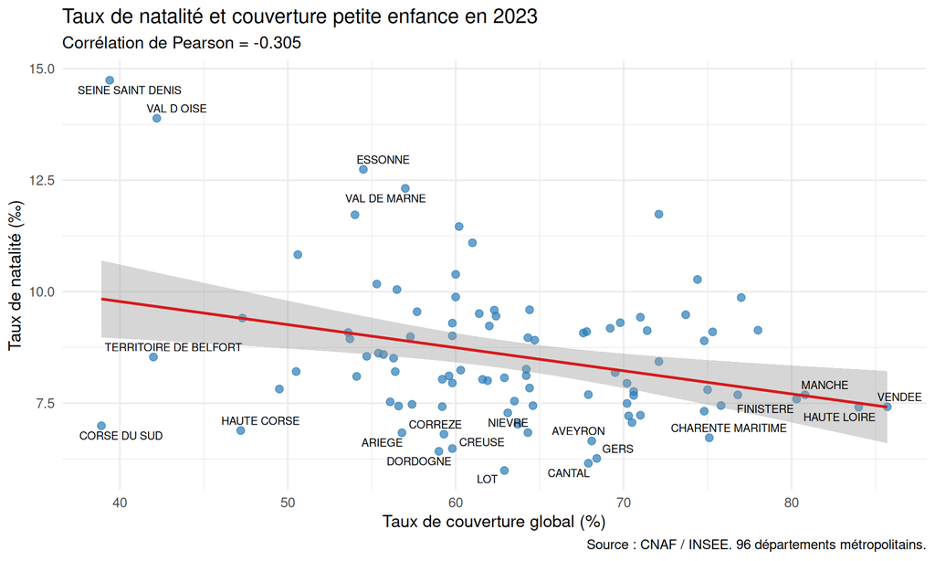

```r
ggplot(final23, aes(x = Taux.de.couv.global, y = taux_natalite_2023)) +
  geom_point(alpha = 0.7, size = 2.5, color = "#2c7bb6") +
  geom_smooth(method = "lm", se = TRUE, color = "#d7191c", linewidth = 1) +
  geom_text_repel(
    data = final23 |>
      filter(taux_natalite_2023 > 12 | taux_natalite_2023 < 7 |
             Taux.de.couv.global > 80 | Taux.de.couv.global < 45),
    aes(label = gsub("^[0-9A-Z]+-", "", département)),
    size = 3, max.overlaps = 12
  ) +
  theme_minimal(base_size = 13) +
  labs(
    title    = "Taux de natalité et couverture petite enfance en 2023",
    subtitle = paste0("Corrélation de Pearson = ",
                      round(cor(final23$taux_natalite_2023,
                                final23$Taux.de.couv.global,
                                use = "complete.obs"), 3)),
    x        = "Taux de couverture global (%)",
    y        = "Taux de natalité (‰)",
    caption  = "Source : CNAF / INSEE. 96 départements métropolitains."
  )
```